# Take Home Examination

**Modul:** Multivariate Geodatenanalyse WS 24/25  
**Bearbeitet von:** Arvo Klöck | 909003  
**Variante:** „Beschäftigte Tertiärer Sektor” // Bandbreitenverfügbarkeit mindestens 50 Mbit/s“

## Vorbereitung der Entwicklungsumgebung

- **a) Setzen des Arbeitsverzeichnisses**  
  Bitte vor dem Ausführen auf den Ordner anpassen, in dem diese Datei liegt.
- **b) Benötigten Pakete laden**  
  Die Funktion `install_and_load` installiert/läd ein Paket, falls es noch nicht installiert ist.

```r
knitr::opts_chunk$set(encoding = "UTF-8")

# a)
setwd("E:/srv/repos/spatial_correlation")

# b)
install_and_load <- function(package) {
  if (!require(package, character.only = TRUE)) {
    install.packages(package, dependencies = TRUE)
    library(package, character.only = TRUE)
  }
}
packages <- c("sf", "tmap", "dplyr", "classInt", "ggplot2","readr","tidyr")
invisible(lapply(packages, install_and_load))

print_installed_packages <- function(packages) {
  installed <- installed.packages()[, c("Package", "Version")]
  installed <- installed[installed[, "Package"] %in% packages, ]
  print(as.data.frame(installed))
}
print_installed_packages(packages)
```

```
##           Package Version
## classInt classInt  0.4-10
## dplyr       dplyr   1.1.4
## ggplot2   ggplot2   3.5.1
## readr       readr   2.1.5
## sf             sf  1.0-19
## tidyr       tidyr   1.3.1
## tmap         tmap   3.3-4
```

## 1. Aufgabenteil

- **a) CSV als Dataframe Objekt importieren**
- **b) Tabellenspalten Definieren**
- **c) Dataframe als RDS im Arbeitsverzeichnis speichern**

```r
# a)
rohdaten <- as.data.frame(read_csv2("909003.csv", col_names = TRUE))
# b)
colnames(rohdaten) <- c("ID", "Region", "Typ", "Beschaeftigte", "Bandbreite")
# c)
saveRDS(rohdaten, file = "909003.rds")
```

## 2. Aufgabenteil

- **a) Klassenanzahl berechnen: Sturges-Formel**  
  Angemessene Balance zwischen Übersichtlichkeit und Detailtreue
- **b) Histogramm der Bandbreite**  
  `bins` ist die Anzahl der Klassen im Histogramm.

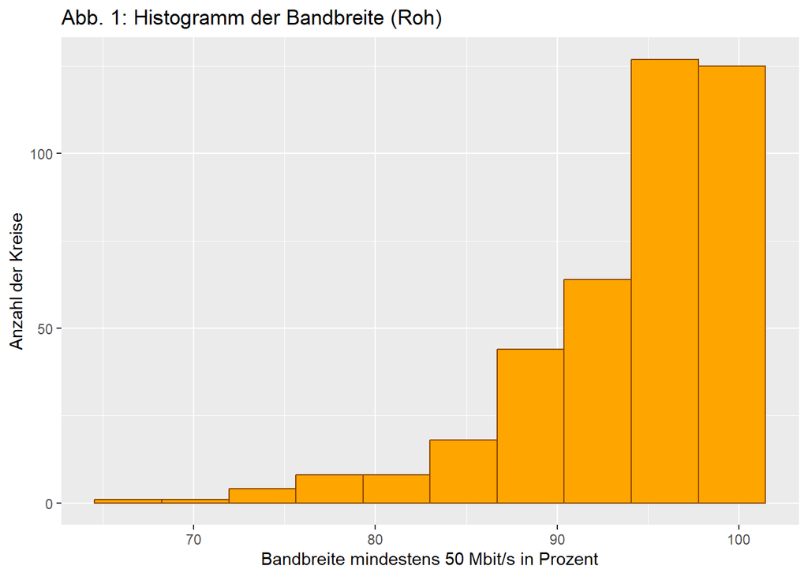

```r
# a)
k_bandbreite <- ceiling(log2(length(rohdaten$Bandbreite)) + 1)

# b)
ggplot(rohdaten, aes(x = Bandbreite)) +
  geom_histogram(bins = k_bandbreite, fill = "orange", color = "darkorange4") +
  labs(title = "Abb. 1: Histogramm der Bandbreite (Roh)", x = "Bandbreite mindestens 50 Mbit/s in Prozent", y = "Anzahl der Kreise")
```

- **c) Klassenanzahl berechnen: Sturges-Formel**  
  Angemessene Balance zwischen Übersichtlichkeit und Detailtreue (Eigentlich redundant)
- **d) Histogramm der Beschäftigten**  
  `bins` ist die Anzahl der Klassen im Histogramm.

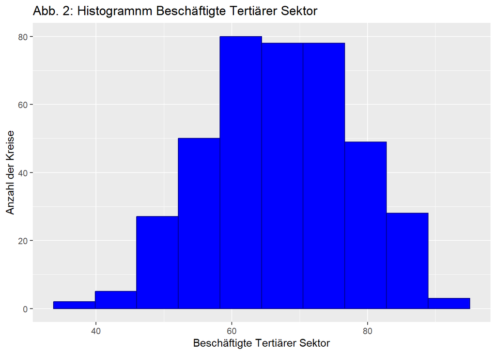

```r
# c)
k_beschaeftigte <- ceiling(log2(length(rohdaten$Beschaeftigte)) + 1)
# d)
ggplot(rohdaten, aes(x = Beschaeftigte)) +
  geom_histogram(bins = k_beschaeftigte, fill = "blue", color = "blue4") +
  labs(title = "Abb. 2: Histogramnm Beschäftigte Tertiärer Sektor ", x = "Beschäftigte Tertiärer Sektor", y = "Anzahl der Kreise")
```

`Abb 2.`

> - Normalverteilt
> - Leicht rechtsschief
- **e) Boxplot der beiden Variablen**

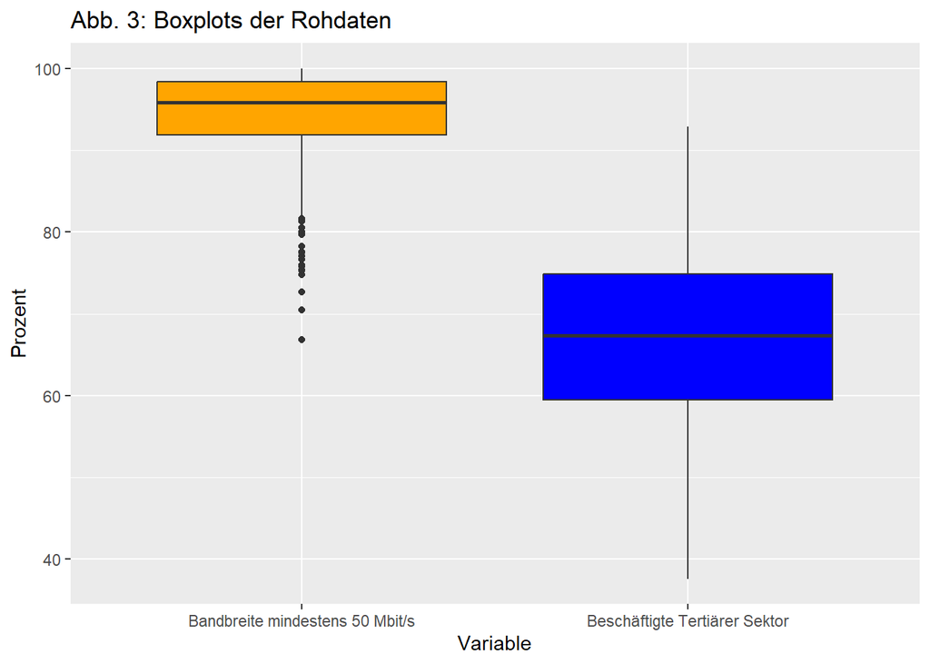

```r
# e)
ggplot(rohdaten %>% pivot_longer(cols = c(Bandbreite, Beschaeftigte), names_to = "Variable", values_to = "Wert"), aes(x = Variable, y = Wert)) +
  geom_boxplot(fill = c("orange", "blue")) +
  labs(title = "Abb. 3: Boxplots der Rohdaten", x = "Variable", y = "Prozent") +
  scale_x_discrete(labels = c("Bandbreite mindestens 50 Mbit/s", "Beschäftigte Tertiärer Sektor"))
```